# Supervised Learning - Project: ReCell

## Problem Statement

### Business Context

Buying and selling used phones and tablets used to be something that happened on a handful of online marketplace sites. But the used and refurbished device market has grown considerably over the past decade, and a new IDC (International Data Corporation) forecast predicts that the used phone market would be worth \$52.7bn by 2023 with a compound annual growth rate (CAGR) of 13.6% from 2018 to 2023. This growth can be attributed to an uptick in demand for used phones and tablets that offer considerable savings compared with new models.

Refurbished and used devices continue to provide cost-effective alternatives to both consumers and businesses that are looking to save money when purchasing one. There are plenty of other benefits associated with the used device market. Used and refurbished devices can be sold with warranties and can also be insured with proof of purchase. Third-party vendors/platforms, such as Verizon, Amazon, etc., provide attractive offers to customers for refurbished devices. Maximizing the longevity of devices through second-hand trade also reduces their environmental impact and helps in recycling and reducing waste. The impact of the COVID-19 outbreak may further boost this segment as consumers cut back on discretionary spending and buy phones and tablets only for immediate needs.

### Objective

The rising potential of this comparatively under-the-radar market fuels the need for an ML-based solution to develop a dynamic pricing strategy for used and refurbished devices. ReCell, a startup aiming to tap the potential in this market, has hired you as a data scientist. They want you to analyze the data provided and build a linear regression model to predict the price of a used phone/tablet and identify factors that significantly influence it.

### Data Description

The data contains the different attributes of used/refurbished phones and tablets. The data was collected in the year 2021. The detailed data dictionary is given below.

- brand_name: Name of manufacturing brand
- os: OS on which the device runs
- screen_size: Size of the screen in cm
- 4g: Whether 4G is available or not
- 5g: Whether 5G is available or not
- main_camera_mp: Resolution of the rear camera in megapixels
- selfie_camera_mp: Resolution of the front camera in megapixels
- int_memory: Amount of internal memory (ROM) in GB
- ram: Amount of RAM in GB
- battery: Energy capacity of the device battery in mAh
- weight: Weight of the device in grams
- release_year: Year when the device model was released
- days_used: Number of days the used/refurbished device has been used
- normalized_new_price: Normalized price of a new device of the same model in euros
- normalized_used_price: Normalized price of the used/refurbished device in euros

## Importing necessary libraries

```python
# Libraries to help with reading and manipulating data
import numpy as np
import pandas as pd

# Libraries to help with data visualization
import matplotlib.pyplot as plt
import seaborn as sns

sns.set()

# split the data into train and test
from sklearn.model_selection import train_test_split

# to build linear regression_model
from sklearn.linear_model import LinearRegression

# to check model performance
from sklearn.metrics import mean_absolute_error, mean_squared_error, r2_score

# to build linear regression_model using statsmodels
import statsmodels.api as sm

# to compute VIF
from statsmodels.stats.outliers_influence import variance_inflation_factor
```

## Loading the dataset

```python
# Mounting Google Drive to the notebook
from google.colab import drive

drive.mount("/content/drive")
```

```python
# loading data
data = pd.read_csv('/content/drive/MyDrive/PGP-DSBA/used_device_data.csv')
```

## Data Overview

The initial steps to get an overview of any dataset is to:

- observe the first few rows of the dataset, to check whether the dataset has been loaded properly or not
- get information about the number of rows and columns in the dataset
- find out the data types of the columns to ensure that data is stored in the preferred format and the value of each property is as expected.
- check the statistical summary of the dataset to get an overview of the numerical columns of the data

### Displaying the first few rows of the dataset

```python
data.head()
```

|  | brand_name | os | screen_size | 4g | 5g | main_camera_mp | selfie_camera_mp | int_memory | ram | battery | weight | release_year | days_used | normalized_used_price | normalized_new_price |
| --- | --- | --- | --- | --- | --- | --- | --- | --- | --- | --- | --- | --- | --- | --- | --- |
| 0 | Honor | Android | 14.50 | yes | no | 13.0 | 5.0 | 64.0 | 3.0 | 3020.0 | 146.0 | 2020 | 127 | 4.307572 | 4.715100 |
| 1 | Honor | Android | 17.30 | yes | yes | 13.0 | 16.0 | 128.0 | 8.0 | 4300.0 | 213.0 | 2020 | 325 | 5.162097 | 5.519018 |
| 2 | Honor | Android | 16.69 | yes | yes | 13.0 | 8.0 | 128.0 | 8.0 | 4200.0 | 213.0 | 2020 | 162 | 5.111084 | 5.884631 |
| 3 | Honor | Android | 25.50 | yes | yes | 13.0 | 8.0 | 64.0 | 6.0 | 7250.0 | 480.0 | 2020 | 345 | 5.135387 | 5.630961 |
| 4 | Honor | Android | 15.32 | yes | no | 13.0 | 8.0 | 64.0 | 3.0 | 5000.0 | 185.0 | 2020 | 293 | 4.389995 | 4.947837 |

### Checking the shape of the dataset

```python
data.shape
```

```
(3454, 15)
```

The dataset has 3,454 rows and 15 columns of data.

### Checking the data types of the columns for the dataset

```python
data.info()
```

```
<class 'pandas.core.frame.DataFrame'>
RangeIndex: 3454 entries, 0 to 3453
Data columns (total 15 columns):
 #   Column                 Non-Null Count  Dtype
---  ------                 --------------  -----
 0   brand_name             3454 non-null   object
 1   os                     3454 non-null   object
 2   screen_size            3454 non-null   float64
 3   4g                     3454 non-null   object
 4   5g                     3454 non-null   object
 5   main_camera_mp         3275 non-null   float64
 6   selfie_camera_mp       3452 non-null   float64
 7   int_memory             3450 non-null   float64
 8   ram                    3450 non-null   float64
 9   battery                3448 non-null   float64
 10  weight                 3447 non-null   float64
 11  release_year           3454 non-null   int64
 12  days_used              3454 non-null   int64
 13  normalized_used_price  3454 non-null   float64
 14  normalized_new_price   3454 non-null   float64
dtypes: float64(9), int64(2), object(4)
memory usage: 404.9+ KB
```

The dataset contains various data types:

- There are 4 object data types (brand_name, os, 4g, 5g)
- There are 9 float data types (screen_size, main_camera_mp, selfie_camera_mp, int_memory, ram, battery, weight, normalized_used-price, normalized_new_price)
- There are 2 integer data types (release_year, days_used)

### Statistical summary of the dataset

```python
data.describe(include='all').T
```

|  | count | unique | top | freq | mean | std | min | 25% | 50% | 75% | max |
| --- | --- | --- | --- | --- | --- | --- | --- | --- | --- | --- | --- |
| brand_name | 3454 | 34 | Others | 502 | NaN | NaN | NaN | NaN | NaN | NaN | NaN |
| os | 3454 | 4 | Android | 3214 | NaN | NaN | NaN | NaN | NaN | NaN | NaN |
| screen_size | 3454.0 | NaN | NaN | NaN | 13.713115 | 3.80528 | 5.08 | 12.7 | 12.83 | 15.34 | 30.71 |
| 4g | 3454 | 2 | yes | 2335 | NaN | NaN | NaN | NaN | NaN | NaN | NaN |
| 5g | 3454 | 2 | no | 3302 | NaN | NaN | NaN | NaN | NaN | NaN | NaN |
| main_camera_mp | 3275.0 | NaN | NaN | NaN | 9.460208 | 4.815461 | 0.08 | 5.0 | 8.0 | 13.0 | 48.0 |
| selfie_camera_mp | 3452.0 | NaN | NaN | NaN | 6.554229 | 6.970372 | 0.0 | 2.0 | 5.0 | 8.0 | 32.0 |
| int_memory | 3450.0 | NaN | NaN | NaN | 54.573099 | 84.972371 | 0.01 | 16.0 | 32.0 | 64.0 | 1024.0 |
| ram | 3450.0 | NaN | NaN | NaN | 4.036122 | 1.365105 | 0.02 | 4.0 | 4.0 | 4.0 | 12.0 |
| battery | 3448.0 | NaN | NaN | NaN | 3133.402697 | 1299.682844 | 500.0 | 2100.0 | 3000.0 | 4000.0 | 9720.0 |
| weight | 3447.0 | NaN | NaN | NaN | 182.751871 | 88.413228 | 69.0 | 142.0 | 160.0 | 185.0 | 855.0 |
| release_year | 3454.0 | NaN | NaN | NaN | 2015.965258 | 2.298455 | 2013.0 | 2014.0 | 2015.5 | 2018.0 | 2020.0 |
| days_used | 3454.0 | NaN | NaN | NaN | 674.869716 | 248.580166 | 91.0 | 533.5 | 690.5 | 868.75 | 1094.0 |
| normalized_used_price | 3454.0 | NaN | NaN | NaN | 4.364712 | 0.588914 | 1.536867 | 4.033931 | 4.405133 | 4.7557 | 6.619433 |
| normalized_new_price | 3454.0 | NaN | NaN | NaN | 5.233107 | 0.683637 | 2.901422 | 4.790342 | 5.245892 | 5.673718 | 7.847841 |

- The normalized used price varies between \$1.54 and \$6.62 with an average of \$4.36
- The normalized new price varies between \$2.90 and \$7.85 with an average of \$5.23
- Android is the most occurring type of os.
- The RAM of the devices a varies from 0.02 GB to 12 GB with an average of 4.04 GB
- The weight of devices varies from 69g to 855g with an average of 182.75g
- The energy capacity of devices varies from 500 mAh to 9720 mAh with an average of 3133.40 mAh

### Checking for duplicate values

```python
data.duplicated().sum()
```

```
0
```

There are no duplicate values in this dataset.

### Checking for missing values

```python
data.isnull().sum()
```

```
brand_name                 0
os                         0
screen_size                0
4g                         0
5g                         0
main_camera_mp           179
selfie_camera_mp           2
int_memory                 4
ram                        4
battery                    6
weight                     7
release_year               0
days_used                  0
normalized_used_price      0
normalized_new_price       0
dtype: int64
```

There are missing values for the following columns:

- main_camera_mp
- selfie_camera_mp
- int_memory
- ram
- battery
- weight

```python
# creating a copy of the data so that original data remains unchanged
df = data.copy()
```

## Exploratory Data Analysis

### Univariate Analysis

```python
# function to plot a boxplot and a histogram along the same scale.


def histogram_boxplot(data, feature, figsize=(15, 10), kde=False, bins=None):
    """
    Boxplot and histogram combined

    data: dataframe
    feature: dataframe column
    figsize: size of figure (default (15,10))
    kde: whether to show the density curve (default False)
    bins: number of bins for histogram (default None)
    """
    f2, (ax_box2, ax_hist2) = plt.subplots(
        nrows=2,  # Number of rows of the subplot grid= 2
        sharex=True,  # x-axis will be shared among all subplots
        gridspec_kw={"height_ratios": (0.25, 0.75)},
        figsize=figsize,
    )  # creating the 2 subplots
    sns.boxplot(
        data=data, x=feature, ax=ax_box2, showmeans=True, color="violet"
    )  # boxplot will be created and a triangle will indicate the mean value of the column
    sns.histplot(
        data=data, x=feature, kde=kde, ax=ax_hist2, bins=bins
    ) if bins else sns.histplot(
        data=data, x=feature, kde=kde, ax=ax_hist2
    )  # For histogram
    ax_hist2.axvline(
        data[feature].mean(), color="green", linestyle="--"
    )  # Add mean to the histogram
    ax_hist2.axvline(
        data[feature].median(), color="black", linestyle="-"
    )  # Add median to the histogram
```

```python
# function to create labeled barplots


def labeled_barplot(data, feature, perc=False, n=None):
    """
    Barplot with percentage at the top

    data: dataframe
    feature: dataframe column
    perc: whether to display percentages instead of count (default is False)
    n: displays the top n category levels (default is None, i.e., display all levels)
    """

    total = len(data[feature])  # length of the column
    count = data[feature].nunique()
    if n is None:
        plt.figure(figsize=(count + 2, 6))
    else:
        plt.figure(figsize=(n + 2, 6))

    plt.xticks(rotation=90, fontsize=15)
    ax = sns.countplot(
        data=data,
        x=feature,
        palette="Paired",
        order=data[feature].value_counts().index[:n],
    )

    for p in ax.patches:
        if perc == True:
            label = "{:.1f}%".format(
                100 * p.get_height() / total
            )  # percentage of each class of the category
        else:
            label = p.get_height()  # count of each level of the category

        x = p.get_x() + p.get_width() / 2  # width of the plot
        y = p.get_height()  # height of the plot

        ax.annotate(
            label,
            (x, y),
            ha="center",
            va="center",
            size=12,
            xytext=(0, 5),
            textcoords="offset points",
        )  # annotate the percentage

    plt.show()  # show the plot
```

**What does the distribution of normalized used device prices look like?**

**`normalized_used_price`**

```python
df['normalized_used_price'].describe()
```

```
count    3454.000000
mean        4.364712
std         0.588914
min         1.536867
25%         4.033931
50%         4.405133
75%         4.755700
max         6.619433
Name: normalized_used_price, dtype: float64
```

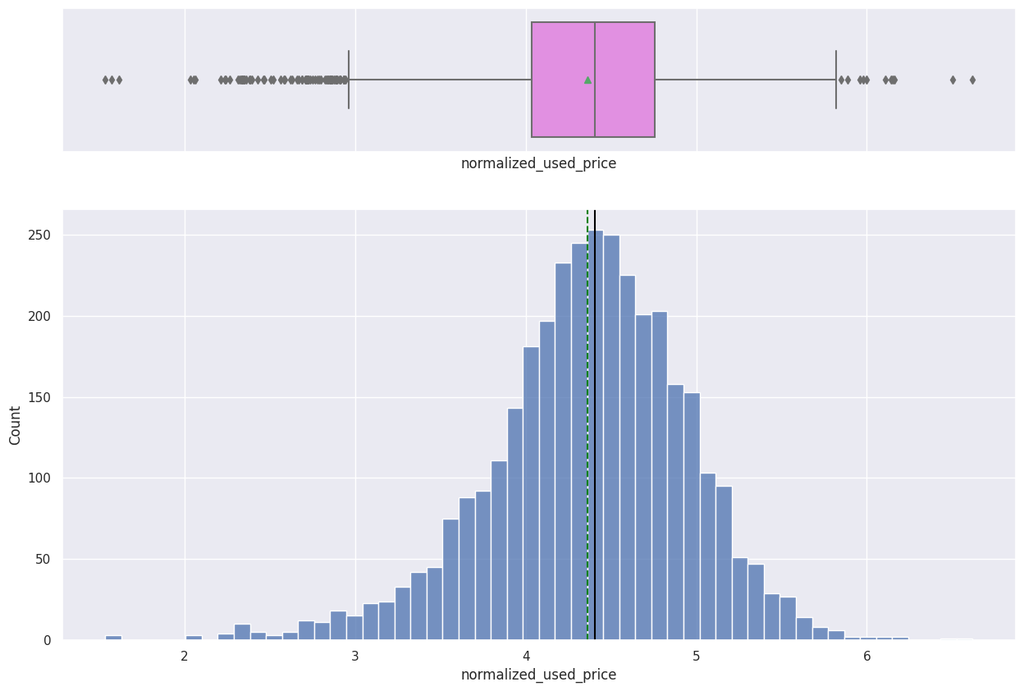

```python
histogram_boxplot(df, "normalized_used_price")
```

- The distribution of the normalized used price for the devices appears to look normal. There seems to be outliers on both the lower and higher ends.
- The average normalized used price for the devices is $4.36.

**`normalized_new_price`**

```python
df['normalized_new_price'].describe()
```

```
count    3454.000000
mean        5.233107
std         0.683637
min         2.901422
25%         4.790342
50%         5.245892
75%         5.673718
max         7.847841
Name: normalized_new_price, dtype: float64
```

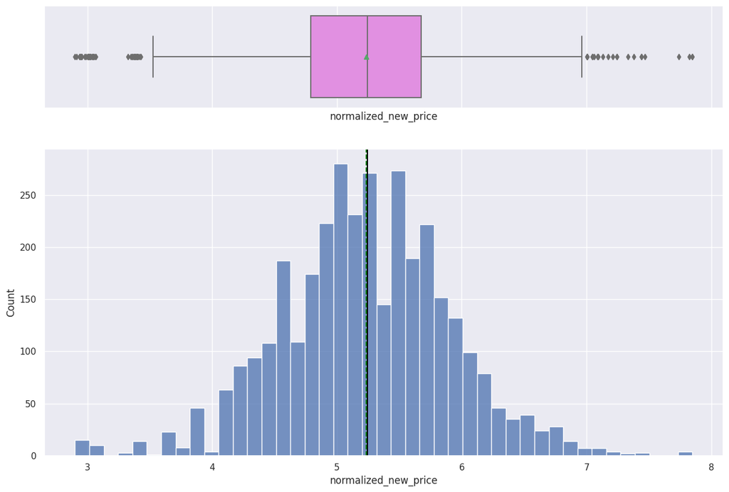

```python
histogram_boxplot(df, 'normalized_new_price')
```

- The distribution of the normalized new price for the devices appears to look normal. There seems to be outliers on both the lower and higher ends.
- The average normalized new price for the devices is $5.23.

**`screen_size`**

```python
df['screen_size'].describe()
```

```
count    3454.000000
mean       13.713115
std         3.805280
min         5.080000
25%        12.700000
50%        12.830000
75%        15.340000
max        30.710000
Name: screen_size, dtype: float64
```

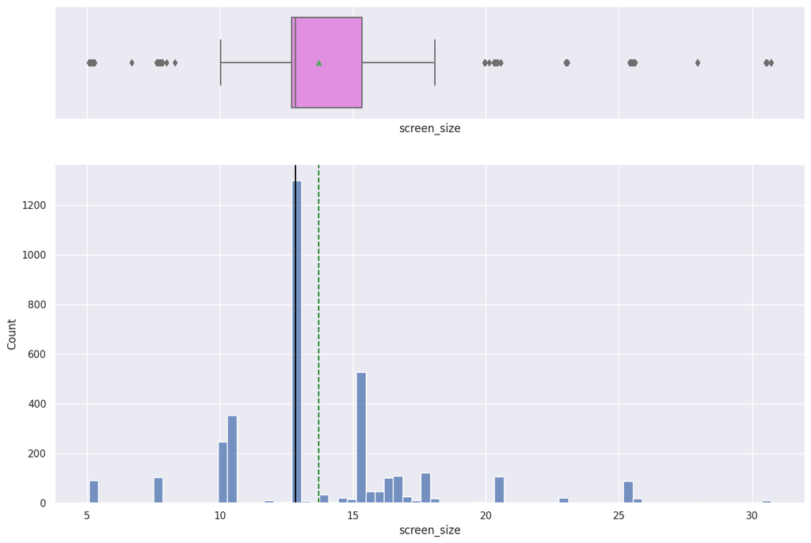

```python
histogram_boxplot(df, 'screen_size')
```

- The distribution of the screen size for the devices appears to not have a clear pattern, although it most closely resembles a normal distribution. There seems to be outliers on both the lower and higher ends.
- The average screen size for the devices is 13.71 cm.

**`main_camera_mp`**

```python
df['main_camera_mp'].describe()
```

```
count    3275.000000
mean        9.460208
std         4.815461
min         0.080000
25%         5.000000
50%         8.000000
75%        13.000000
max        48.000000
Name: main_camera_mp, dtype: float64
```

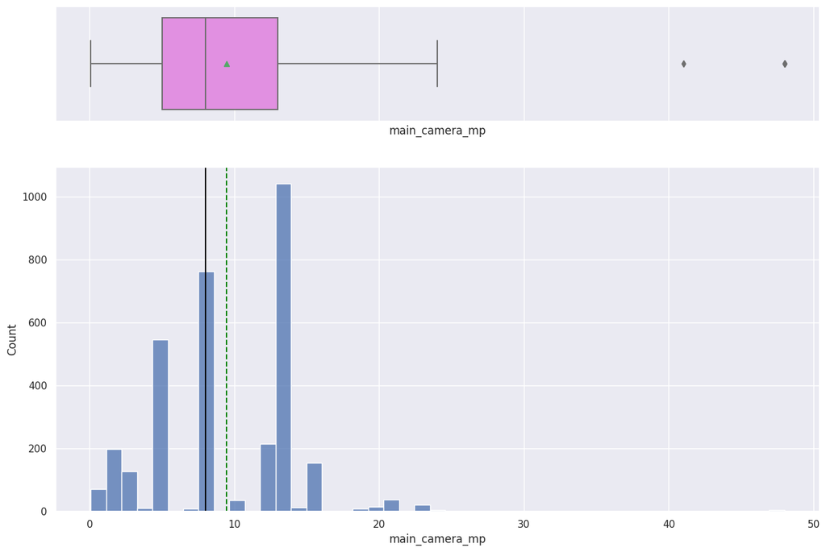

```python
histogram_boxplot(df, 'main_camera_mp')
```

**`selfie_camera_mp`**

```python
df['selfie_camera_mp'].describe()
```

```
count    3452.000000
mean        6.554229
std         6.970372
min         0.000000
25%         2.000000
50%         5.000000
75%         8.000000
max        32.000000
Name: selfie_camera_mp, dtype: float64
```

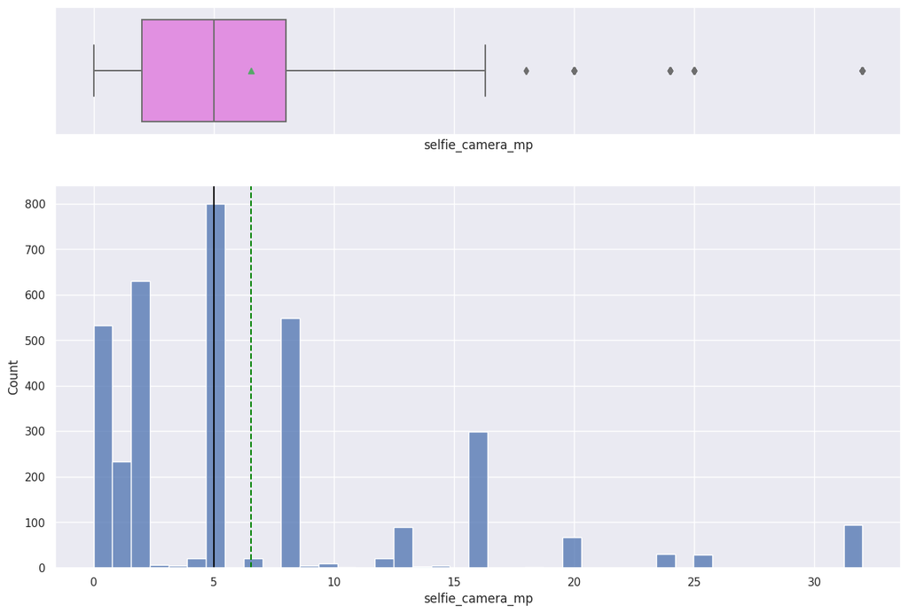

```python
histogram_boxplot(df, 'selfie_camera_mp')
```

- The distribution of the resolution of the selfie camera for the devices appears to be skewed slightly right. There seems to be outliers on the upper end.
- The average resolution of the selfie camera for the devices is 6.55 MP.

**`int_memory`**

```python
df['int_memory'].describe()
```

```
count    3450.000000
mean       54.573099
std        84.972371
min         0.010000
25%        16.000000
50%        32.000000
75%        64.000000
max      1024.000000
Name: int_memory, dtype: float64
```

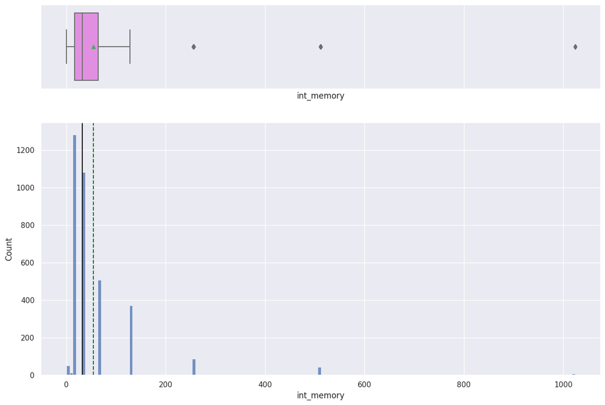

```python
histogram_boxplot(df, 'int_memory')
```

- The distribution of the amount of internal memory for the devices appears to be skewed right. There seems to be outliers on the upper end.
- The average amount of internal memory for the devices is 54.57 GB.

**`ram`**

```python
df['ram'].describe()
```

```
count    3450.000000
mean        4.036122
std         1.365105
min         0.020000
25%         4.000000
50%         4.000000
75%         4.000000
max        12.000000
Name: ram, dtype: float64
```

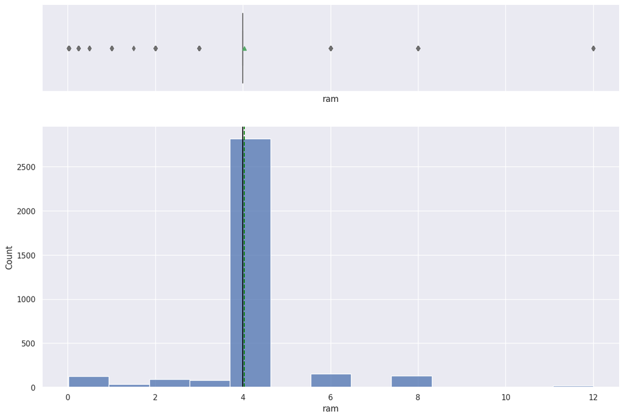

```python
histogram_boxplot(df, 'ram')
```

- There does not seem to be discernable distribution for the amount of RAM for the devices.
- The average amount of RAM for the devices is 4.04 GB.

**`weight`**

```python
df['weight'].describe()
```

```
count    3447.000000
mean      182.751871
std        88.413228
min        69.000000
25%       142.000000
50%       160.000000
75%       185.000000
max       855.000000
Name: weight, dtype: float64
```

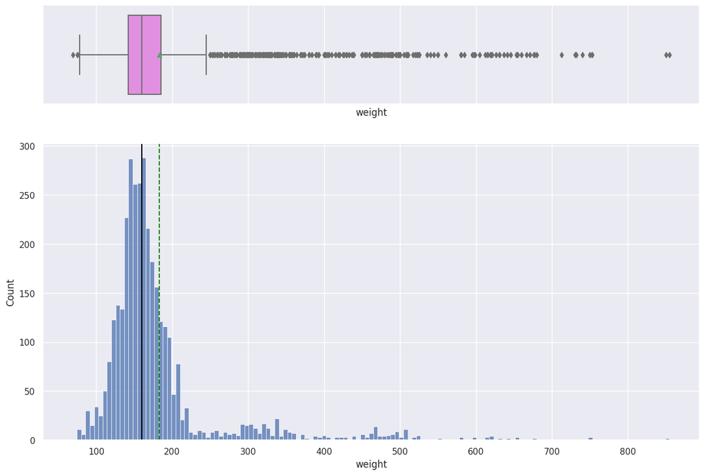

```python
histogram_boxplot(df, 'weight')
```

- The distribution of the weight for the devices appears to be skewed slightly right. There seems to be many outliers on the upper end and some outliers on the lower end.
- The average weight for the devices is 182.75g.

**`battery`**

```python
df['battery'].describe()
```

```
count    3448.000000
mean     3133.402697
std      1299.682844
min       500.000000
25%      2100.000000
50%      3000.000000
75%      4000.000000
max      9720.000000
Name: battery, dtype: float64
```

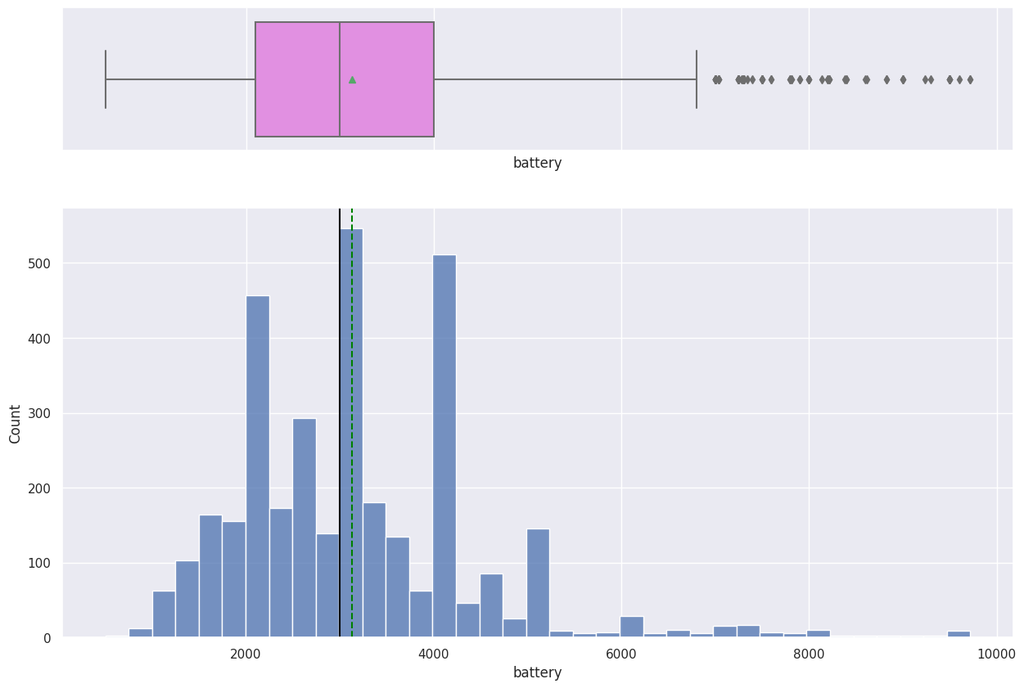

```python
histogram_boxplot(df, 'battery')
```

**`days_used`**

```python
df['days_used'].describe()
```

```
count    3454.000000
mean      674.869716
std       248.580166
min        91.000000
25%       533.500000
50%       690.500000
75%       868.750000
max      1094.000000
Name: days_used, dtype: float64
```

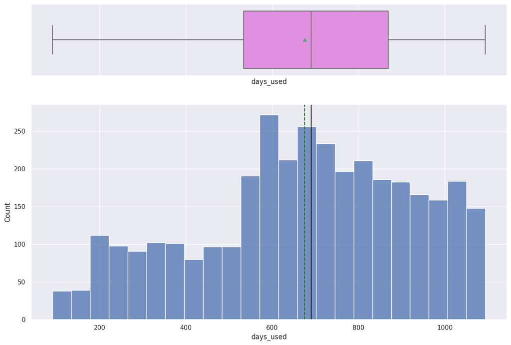

```python
histogram_boxplot(df, 'days_used')
```

- The distribution of the number of days a refurbished product is used appears to be skewed slightly to the left. There seems to be no outliers.
- The average number of days a refurbished product is used is about 675 days.

**`brand_name`**

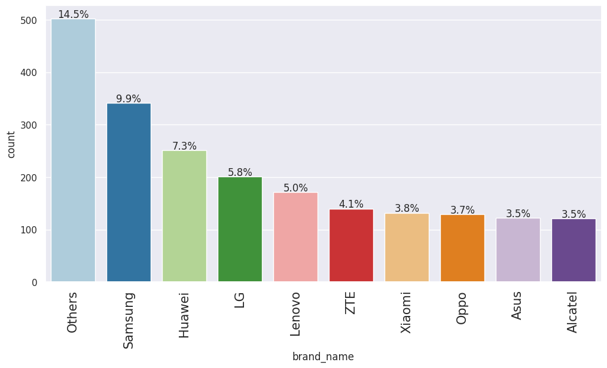

```python
labeled_barplot(df, "brand_name", perc=True, n=10)
```

It appears that various other brand names are the most popular in the used device industry, comprising of 14.5% of the maket. This is followed by Samsung and Huawei with 9.9% and 7.3%, respectively.

**What percentage of the used device market is dominated by Android devices?**

**`os`**

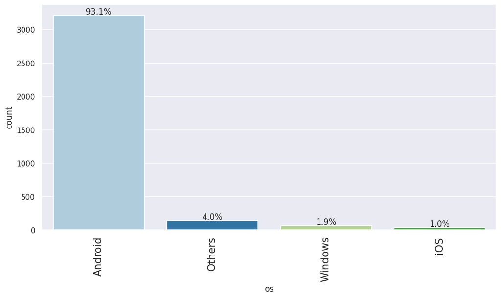

```python
labeled_barplot(df, 'os',perc=True, n=10)
```

It appears that the majority of the used phone market is dominated by Android devices as they make up 93.1% of it. IOS has the smallest market share in the used phone market with 1.0%.

**`4g`**

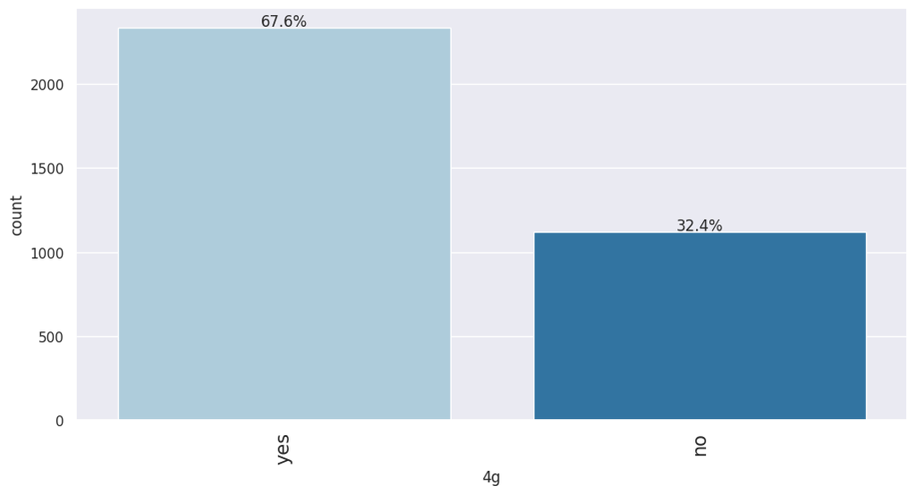

```python
labeled_barplot(df, '4g', perc=True, n=10)
```

Majority of the devices (67.6%) are available with 4g.

**`5g`**

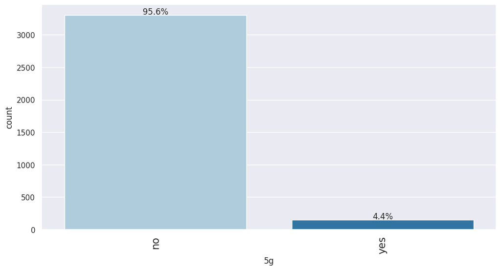

```python
labeled_barplot(df, '5g', perc=True, n=10)
```

Majority of the devices (95.6%) are not availble with 5g.

**`release_year`**

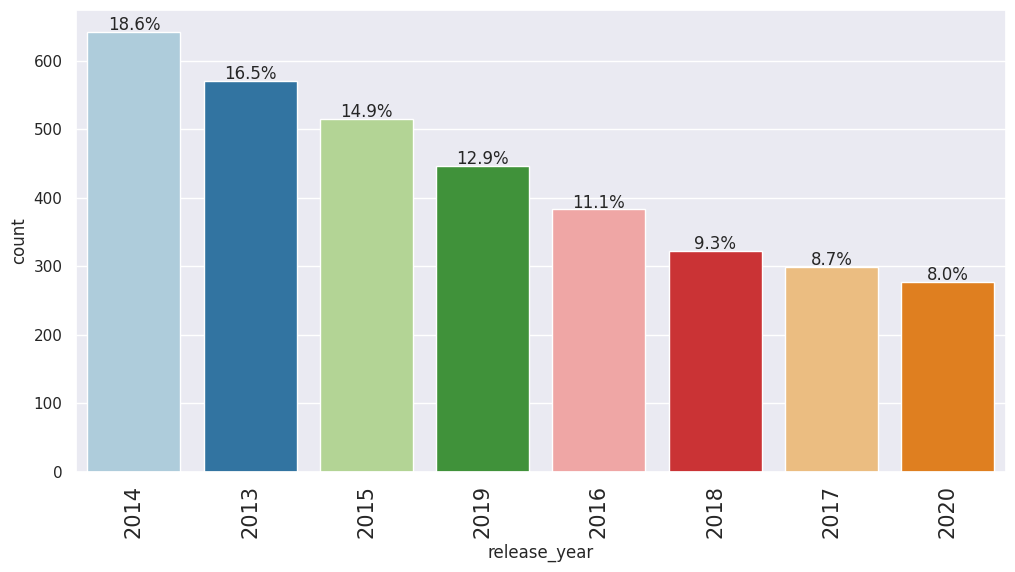

```python
labeled_barplot(df, 'release_year', perc=True, n=10)
```

Many of the devices (18.6%) had a release year of 2014. This is followed by 2013 and 2015 with 16.5% and 14.9%, respectively.

### Bivariate Analysis

**Which attributes are highly correlated with the normalized price of a used device?**

**Correlation Check**

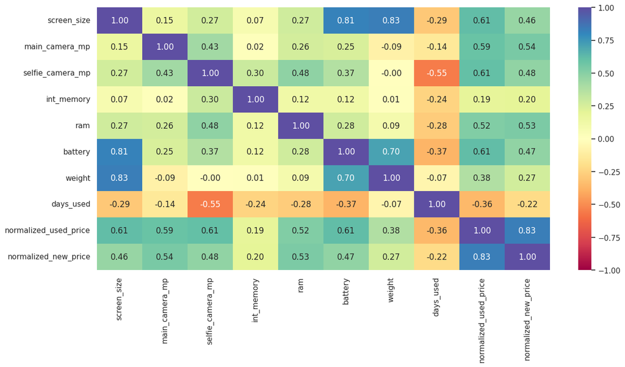

```python
cols_list = df.select_dtypes(include=np.number).columns.tolist()
# dropping release_year as it is a temporal variable
cols_list.remove("release_year")

plt.figure(figsize=(15, 7))
sns.heatmap(
    df[cols_list].corr(), annot=True, vmin=-1, vmax=1, fmt=".2f", cmap="Spectral"
)
plt.show()
```

- The normalized price of a used device is highly positlivly correlated with the normalized new price of the device, the battery capacity, and resolution of the selfie camera, and the screen size.
- The normalized price of the devices is negatively correlated with the number of days the device has been used.

**The amount of RAM is important for the smooth functioning of a device. How does the amount of RAM vary with the brand?**

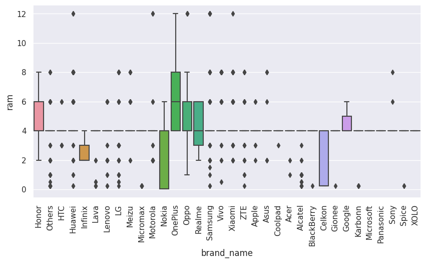

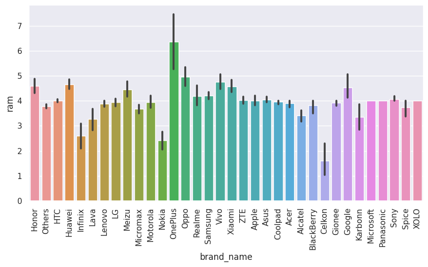

```python
plt.figure(figsize=(10,5))
sns.boxplot(data=df, x="brand_name", y="ram")
plt.xticks(rotation=90)
plt.show()

plt.figure(figsize=(10,5))
plt.xticks(rotation=90)
sns.barplot(data=df, x="brand_name", y="ram")
plt.show()
```

**People who travel frequently require devices with large batteries to run through the day. But large battery often increases weight, making it feel uncomfortable in the hands. Checking how the weight varies for phones offering large batteries (more than 4500 mAh).**

```python
df_large_battery = df[df.battery > 4500]
df_large_battery.shape
```

```
(341, 15)
```

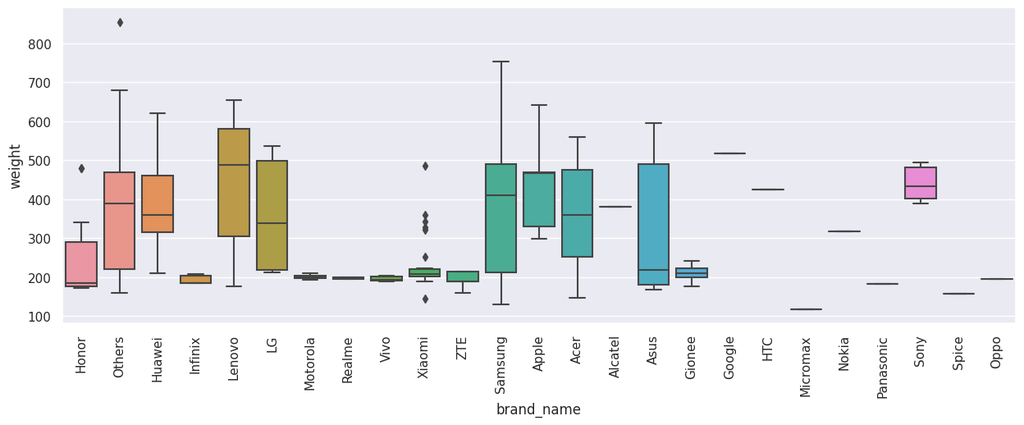

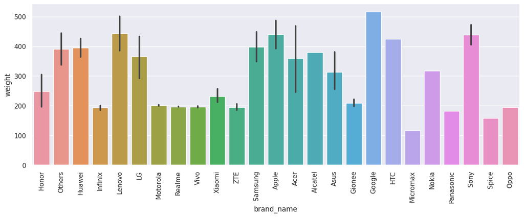

```python
plt.figure(figsize=(15, 5))
sns.boxplot(data=df_large_battery, x="brand_name", y="weight")
plt.xticks(rotation=90)
plt.show()

plt.figure(figsize=(15, 5))
sns.barplot(data=df_large_battery, x="brand_name", y="weight")
plt.xticks(rotation=90)
plt.show()
```

- The distribution of the weight of the devices associated with the brand seems to noticeable different from one another.
- None of the distributions appear the be normally distributed and some brand distributions for the weight have outliers.
- The brand that has the heaviest devices is Google and the brand that has the lightest devices is Micromax

**People who buy phones and tablets primarily for entertainment purposes prefer a large screen as they offer a better viewing experience. How many phones and tablets are available across different brands with a screen size larger than 6 inches?**

```python
df_large_screen = df[df.screen_size > 6 * 2.54]
df_large_screen.shape
```

```
(1099, 15)
```

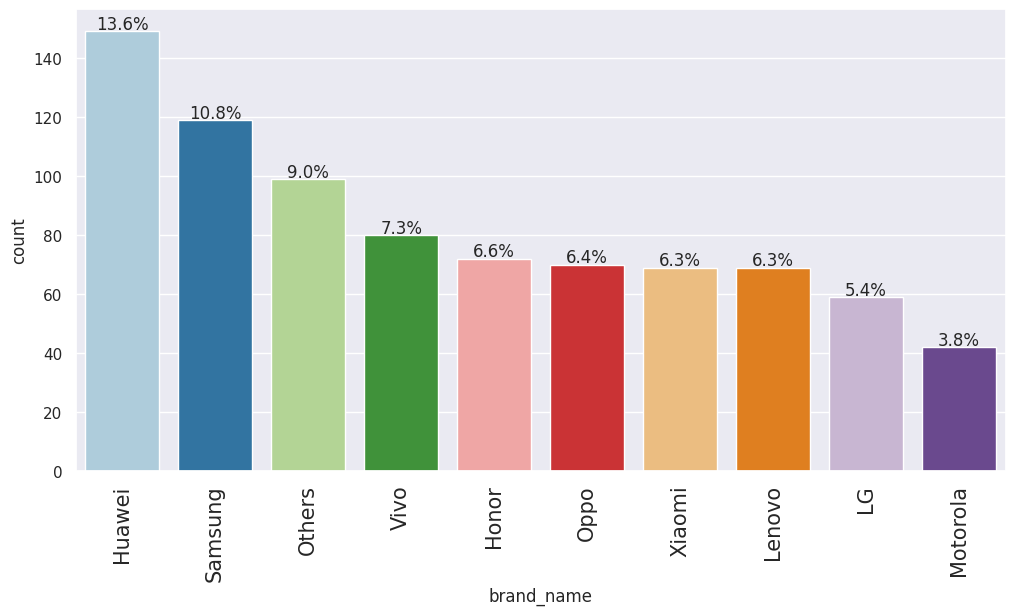

```python
labeled_barplot(df_large_screen, 'brand_name', perc=True, n=10)
```

The brand that has the most amount of devices with screen sizes larger than 6 inches is Huawei, taking up 13.6% of the market. This is followed by Samsung and other miscellaneous brands with market shares of 10.8% and 9%, respectively.

**Everyone likes a good camera to capture their favorite moments with loved ones. Some customers specifically look for good front cameras to click cool selfies. What is the distribution of devices offering greater than 8MP selfie cameras across brands?.**

```python
df_selfie_camera = df[df.selfie_camera_mp > 8]
df_selfie_camera.shape
```

```
(655, 15)
```

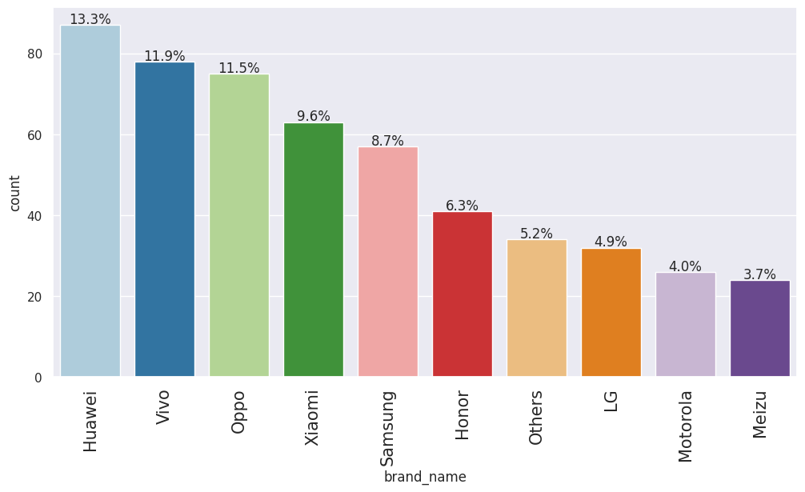

```python
labeled_barplot(df_selfie_camera, 'brand_name', perc=True, n=10)
```

The brand that has the most amount of devices with selfie cameras that have more than 8 MP is Huawei, taking up 13.3% of the market. This is followed by Vivo and Oppo with market shares of 11.9% and 11.5%, respectively.

**Analysis for rear cameras.**

- Rear cameras generally have a better resolution than front cameras, so the threshold is set higher for them at 16MP.

```python
df_main_camera = df[df.main_camera_mp > 16]
df_main_camera.shape
```

```
(94, 15)
```

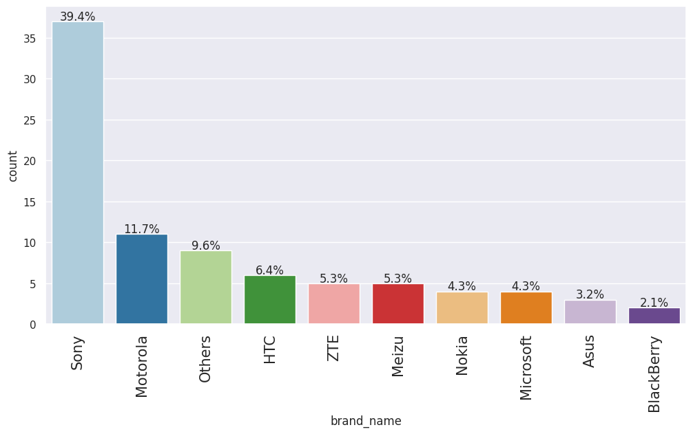

```python
labeled_barplot(df_main_camera, 'brand_name', perc=True, n=10)
```

The brand that has the most amount of devices with main cameras that have more than 16 MP is Sony, taking up 39.4% of the market. This is followed by Motorola and other miscellaneous brands with market shares of 11.7% and 9.6%, respectively.

**Let's see how the price of used devices varies across the years.**

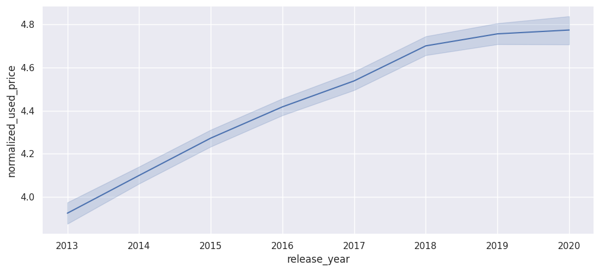

```python
plt.figure(figsize=(12, 5))
sns.lineplot(df, x='release_year', y='normalized_used_price')
plt.show()
```

There appears to a postive relationship between the release year of the device and the normalized used price. As the release year of the devices increases, the normalized used price increases as well.

**Let's check how the prices vary for used phones and tablets offering 4G and 5G networks.**

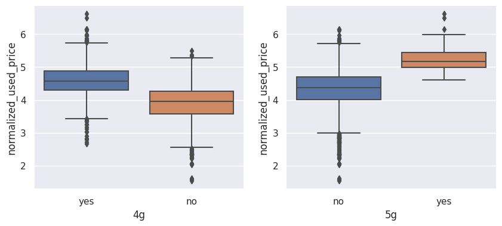

```python
plt.figure(figsize=(10, 4))

plt.subplot(121)
sns.boxplot(data=df, x="4g", y="normalized_used_price")

plt.subplot(122)
sns.boxplot(data=df, x="5g", y="normalized_used_price")

plt.show()
```

- It appears that devices with 4g availbilty have a higher normalized price than devices that don't.
- It appears that devices with 5g availbilty have a higher normalized price than devices that don't.
- Devices that possess 5g have a higher normalized price than devices that possess 4g.

## Data Preprocessing

### Missing Value Imputation

- Impute the missing values in the data by the column medians grouped by `release_year` and `brand_name`.

```python
#create a copy of the data
df1 = df.copy()
```

```python
# checking for missing values
df1.isnull().sum()
```

```
brand_name                 0
os                         0
screen_size                0
4g                         0
5g                         0
main_camera_mp           179
selfie_camera_mp           2
int_memory                 4
ram                        4
battery                    6
weight                     7
release_year               0
days_used                  0
normalized_used_price      0
normalized_new_price       0
dtype: int64
```

There are 6 varaiables with missing values:

- main_camera_mp has 179 missing values
- selfie_camera_mp has 2 missing values
- int_memory has 4 missing values
- ram has 4 missing values
- battery has 6 missing values
- weight has 7 missing values

```python
# creating a list of variables that contain missing values
cols_impute = [
    "main_camera_mp",
    "selfie_camera_mp",
    "int_memory",
    "ram",
    "battery",
    "weight",
]

 # imputing missing values in cols_impute with median by grouping the data on release year and brand name
for col in cols_impute:
    df1[col] = df1[col].fillna(
        value=df1.groupby(['release_year','brand_name'])[col].transform("median")
    )
# checking for missing values
df1.isnull().sum()
```

```
brand_name                 0
os                         0
screen_size                0
4g                         0
5g                         0
main_camera_mp           179
selfie_camera_mp           2
int_memory                 0
ram                        0
battery                    6
weight                     7
release_year               0
days_used                  0
normalized_used_price      0
normalized_new_price       0
dtype: int64
```

- Impute the remaining missing values in the data by the column medians grouped by `brand_name`.

```python
# creating a list of variables that contain missing values
cols_impute = [
    "main_camera_mp",
    "selfie_camera_mp",
    "battery",
    "weight",
]

## imputing the missing values in cols_impute with median by grouping the data on brand name
for col in cols_impute:
    df1[col] = df1[col].fillna(
        value=df1.groupby(['brand_name'])[col].transform("median")
    )

# checking for missing values
df1.isnull().sum()
```

```
brand_name                0
os                        0
screen_size               0
4g                        0
5g                        0
main_camera_mp           10
selfie_camera_mp          0
int_memory                0
ram                       0
battery                   0
weight                    0
release_year              0
days_used                 0
normalized_used_price     0
normalized_new_price      0
dtype: int64
```

```python
## impute the data with median
df1["main_camera_mp"] = df1["main_camera_mp"].fillna(df1["main_camera_mp"].median)

# checking for missing values
df1.isnull().sum()
```

```
brand_name               0
os                       0
screen_size              0
4g                       0
5g                       0
main_camera_mp           0
selfie_camera_mp         0
int_memory               0
ram                      0
battery                  0
weight                   0
release_year             0
days_used                0
normalized_used_price    0
normalized_new_price     0
dtype: int64
```

All missing values have been treated.

### Feature Engineering

- Let's create a new column `years_since_release` from the `release_year` column.
- We will consider the year of data collection, 2021, as the baseline.
- We will drop the `release_year` column.

```python
df1["years_since_release"] = 2021 - df1["release_year"]
df1.drop("release_year", axis=1, inplace=True)
df1["years_since_release"].describe()
```

```
count    3454.000000
mean        5.034742
std         2.298455
min         1.000000
25%         3.000000
50%         5.500000
75%         7.000000
max         8.000000
Name: years_since_release, dtype: float64
```

### Outlier Check

- Let's check for outliers in the data.

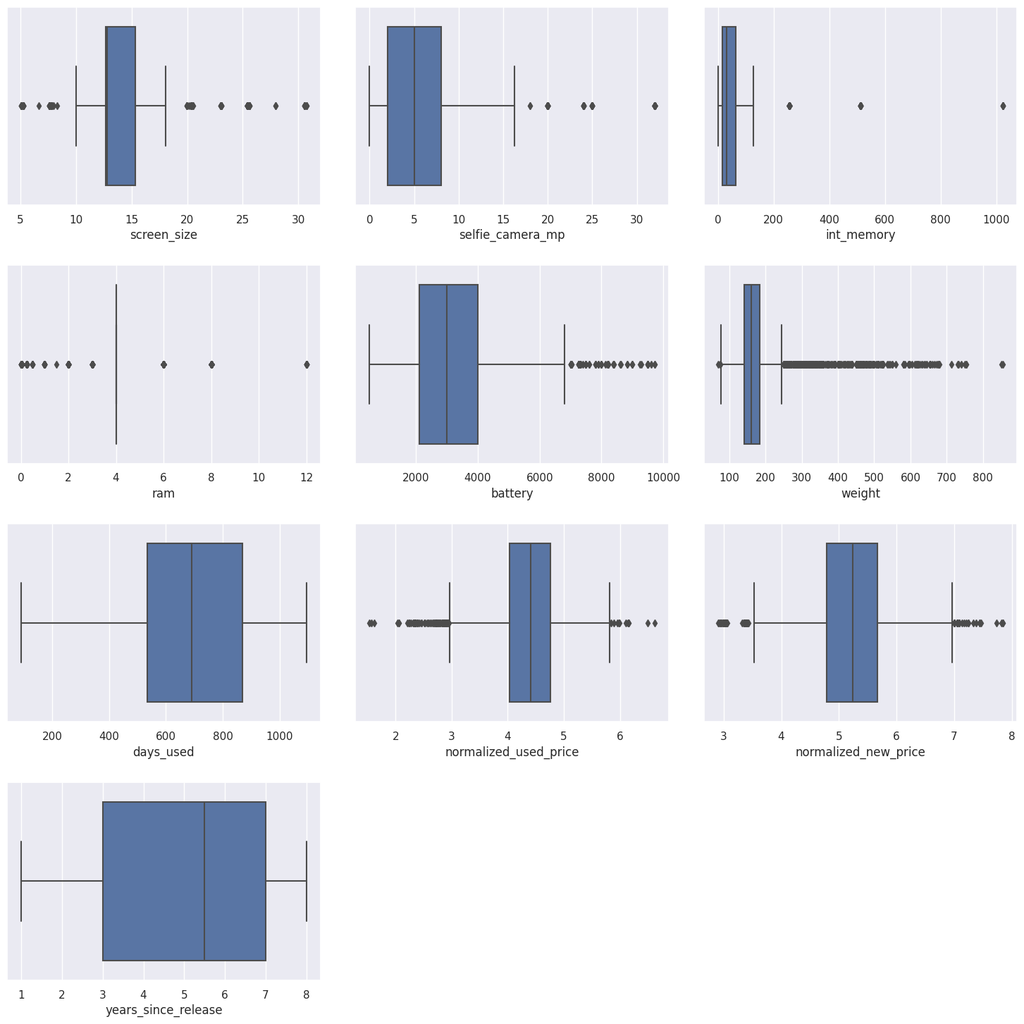

```python
# outlier detection using boxplot
num_cols = df1.select_dtypes(include=np.number).columns.tolist()

plt.figure(figsize=(15, 15))

for i, variable in enumerate(num_cols):
    plt.subplot(4, 3, i + 1)
    sns.boxplot(data=df1, x=variable)
    plt.tight_layout(pad=2)

plt.show()
```

- There are quite a few outliers in the data
- However, we will not treat them as they are proper values

### Data Preparation for modeling

- We want to predict the normalized price of used devices
- Before we proceed to build a model, we'll have to encode categorical features
- We'll split the data into train and test to be able to evaluate the model that we build on the train data
- We will build a Linear Regression model using the train data and then check it's performance

```python
# define the dependent and independent variables
X = df1.drop(['normalized_used_price'], axis=1)
y = df1['normalized_used_price']

print(X.head())
print()
print(y.head())
```

```
  brand_name       os  screen_size   4g   5g main_camera_mp  selfie_camera_mp  \
0      Honor  Android        14.50  yes   no           13.0               5.0
1      Honor  Android        17.30  yes  yes           13.0              16.0
2      Honor  Android        16.69  yes  yes           13.0               8.0
3      Honor  Android        25.50  yes  yes           13.0               8.0
4      Honor  Android        15.32  yes   no           13.0               8.0

   int_memory  ram  battery  weight  days_used  normalized_new_price  \
0        64.0  3.0   3020.0   146.0        127              4.715100
1       128.0  8.0   4300.0   213.0        325              5.519018
2       128.0  8.0   4200.0   213.0        162              5.884631
3        64.0  6.0   7250.0   480.0        345              5.630961
4        64.0  3.0   5000.0   185.0        293              4.947837

   years_since_release
0                    1
1                    1
2                    1
3                    1
4                    1

0    4.307572
1    5.162097
2    5.111084
3    5.135387
4    4.389995
Name: normalized_used_price, dtype: float64
```

```python
# add the intercept to data
X = sm.add_constant(X)
```

```python
# creating dummy variables
X = pd.get_dummies(
    X,
    columns=X.select_dtypes(include=['object','category']).columns.tolist(),
    drop_first=True,
)

X = X.astype(float)

X.head()
```

|  | const | screen_size | selfie_camera_mp | int_memory | ram | battery | weight | days_used | normalized_new_price | years_since_release | ... | main_camera_mp_20.1 | main_camera_mp_12.6 | main_camera_mp_16.3 | main_camera_mp_22.6 | main_camera_mp_19.0 | main_camera_mp_21.5 | main_camera_mp_21.2 | main_camera_mp_8.1 | main_camera_mp_1.2 | main_camera_mp_22.5 |
| --- | --- | --- | --- | --- | --- | --- | --- | --- | --- | --- | --- | --- | --- | --- | --- | --- | --- | --- | --- | --- | --- |
| 0 | 1.0 | 14.50 | 5.0 | 64.0 | 3.0 | 3020.0 | 146.0 | 127.0 | 4.715100 | 1.0 | ... | 0.0 | 0.0 | 0.0 | 0.0 | 0.0 | 0.0 | 0.0 | 0.0 | 0.0 | 0.0 |
| 1 | 1.0 | 17.30 | 16.0 | 128.0 | 8.0 | 4300.0 | 213.0 | 325.0 | 5.519018 | 1.0 | ... | 0.0 | 0.0 | 0.0 | 0.0 | 0.0 | 0.0 | 0.0 | 0.0 | 0.0 | 0.0 |
| 2 | 1.0 | 16.69 | 8.0 | 128.0 | 8.0 | 4200.0 | 213.0 | 162.0 | 5.884631 | 1.0 | ... | 0.0 | 0.0 | 0.0 | 0.0 | 0.0 | 0.0 | 0.0 | 0.0 | 0.0 | 0.0 |
| 3 | 1.0 | 25.50 | 8.0 | 64.0 | 6.0 | 7250.0 | 480.0 | 345.0 | 5.630961 | 1.0 | ... | 0.0 | 0.0 | 0.0 | 0.0 | 0.0 | 0.0 | 0.0 | 0.0 | 0.0 | 0.0 |
| 4 | 1.0 | 15.32 | 8.0 | 64.0 | 3.0 | 5000.0 | 185.0 | 293.0 | 4.947837 | 1.0 | ... | 0.0 | 0.0 | 0.0 | 0.0 | 0.0 | 0.0 | 0.0 | 0.0 | 0.0 | 0.0 |

5 rows × 89 columns

```python
# splitting the data in 70:30 ratio for train to test data

x_train, x_test, y_train, y_test =  train_test_split(X, y, test_size=0.3, random_state=1)
```

```python
print("Number of rows in train data =", x_train.shape[0])
print("Number of rows in test data =", x_test.shape[0])
```

```
Number of rows in train data = 2417
Number of rows in test data = 1037
```

## Model Building - Linear Regression

```python
# Create a fit OLS model
olsmodel1 = sm.OLS(y_train, x_train).fit()
print(olsmodel1.summary())
```

```
                              OLS Regression Results
=================================================================================
Dep. Variable:     normalized_used_price   R-squared:                       0.850
Model:                               OLS   Adj. R-squared:                  0.845
Method:                    Least Squares   F-statistic:                     159.2
Date:                   Sun, 28 May 2023   Prob (F-statistic):               0.00
Time:                           06:31:19   Log-Likelihood:                 163.90
No. Observations:                   2417   AIC:                            -159.8
Df Residuals:                       2333   BIC:                             326.6
Df Model:                             83
Covariance Type:               nonrobust
============================================================================================================================================================================================================================================================================================================…
                                                                                                                                                                                                                                                                                         coef    std err    …
------------------------------------------------------------------------------------------------------------------------------------------------------------------------------------------------------------------------------------------------------------------------------------------------------------…
const                                                                                                                                                                                                                                                                                  1.6815      0.080    …
screen_size                                                                                                                                                                                                                                                                            0.0238      0.003    …
selfie_camera_mp                                                                                                                                                                                                                                                                       0.0137      0.001    …
int_memory                                                                                                                                                                                                                                                                             0.0002   7.09e-05    …
ram                                                                                                                                                                                                                                                                                    0.0223      0.005    …
battery                                                                                                                                                                                                                                                                            -1.753e-05   7.39e-06    …
weight                                                                                                                                                                                                                                                                                 0.0011      0.000    …
days_used                                                                                                                                                                                                                                                                           2.496e-05   3.11e-05    …
normalized_new_price                                                                                                                                                                                                                                                                   0.4146      0.013    …
years_since_release                                                                                                                                                                                                                                                                   -0.0213      0.005    …
brand_name_Alcatel                                                                                                                                                                                                                                                                     0.0093      0.047    …
brand_name_Apple                                                                                                                                                                                                                                                                      -0.1129      0.147    …
```

[output cut: 99 more lines]

### Interpreting the Regression Results:

1. **Adjusted. R-squared**: It reflects the fit of the model.
   - Adjusted R-squared values generally range from 0 to 1, where a higher value generally indicates a better fit, assuming certain conditions are met.
   - In our case, the value for adj. R-squared is **0.845**, which is good.
1. *const* coefficient: It is the Y-intercept.
   - It means that if all the predictor variable coefficients are zero, then the expected output (i.e., Y) would be equal to the *const* coefficient.
   - In our case, the value for `const` coefficient is **1.6815**
1. **Coefficient of a predictor variable**: It represents the change in the output Y due to a change in the predictor variable (everything else held constant).
   - For example, the coefficient of `normalized_new_price` is **0.4146**.

### Model Performance Check

**Let's check the performance of the model using different metrics.**

- We will be using metric functions defined in sklearn for RMSE, MAE, and $R^2$.
- We will define a function to calculate MAPE and adjusted $R^2$.
- We will create a function which will print out all the above metrics in one go.

```python
# function to compute adjusted R-squared
def adj_r2_score(predictors, targets, predictions):
    r2 = r2_score(targets, predictions)
    n = predictors.shape[0]
    k = predictors.shape[1]
    return 1 - ((1 - r2) * (n - 1) / (n - k - 1))


# function to compute MAPE
def mape_score(targets, predictions):
    return np.mean(np.abs(targets - predictions) / targets) * 100


# function to compute different metrics to check performance of a regression model
def model_performance_regression(model, predictors, target):
    """
    Function to compute different metrics to check regression model performance

    model: regressor
    predictors: independent variables
    target: dependent variable
    """

    # predicting using the independent variables
    pred = model.predict(predictors)

    r2 = r2_score(target, pred)  # to compute R-squared
    adjr2 = adj_r2_score(predictors, target, pred)  # to compute adjusted R-squared
    rmse = np.sqrt(mean_squared_error(target, pred))  # to compute RMSE
    mae = mean_absolute_error(target, pred)  # to compute MAE
    mape = mape_score(target, pred)  # to compute MAPE

    # creating a dataframe of metrics
    df_perf = pd.DataFrame(
        {
            "RMSE": rmse,
            "MAE": mae,
            "R-squared": r2,
            "Adj. R-squared": adjr2,
            "MAPE": mape,
        },
        index=[0],
    )

    return df_perf
```

```python
# checking model performance on train set (seen 70% data)
print("Training Performance\n")
olsmodel1_train_perf = model_performance_regression(olsmodel1, x_train, y_train)
olsmodel1_train_perf
```

```
Training Performance
```

|  | RMSE | MAE | R-squared | Adj. R-squared | MAPE |
| --- | --- | --- | --- | --- | --- |
| 0 | 0.226107 | 0.17736 | 0.849942 | 0.844202 | 4.247918 |

```python
# checking model performance on test set (seen 30% data)
print("Test Performance\n")
olsmodel1_test_perf = model_performance_regression(olsmodel1, x_test, y_test)
olsmodel1_test_perf
```

```
Test Performance
```

|  | RMSE | MAE | R-squared | Adj. R-squared | MAPE |
| --- | --- | --- | --- | --- | --- |
| 0 | 0.239404 | 0.185272 | 0.841094 | 0.82616 | 4.495925 |

## Checking Linear Regression Assumptions

We will be checking the following Linear Regression assumptions:

1. **No Multicollinearity**
2. **Linearity of variables**
3. **Independence of error terms**
4. **Normality of error terms**
5. **No Heteroscedasticity**

### TEST FOR MULTICOLLINEARITY

- We will test for multicollinearity using VIF.
- **General Rule of thumb**:
  - If VIF is 1 then there is no correlation between the $k$th predictor and the remaining predictor variables.
  - If VIF exceeds 5 or is close to exceeding 5, we say there is moderate multicollinearity.
  - If VIF is 10 or exceeding 10, it shows signs of high multicollinearity.

Let's define a function to check VIF.

```python
# define a function to check VIF.

def checking_vif(predictors):
    vif = pd.DataFrame()
    vif["feature"] = predictors.columns

    # calculating VIF for each feature
    vif["VIF"] = [
        variance_inflation_factor(predictors.values, i)
        for i in range(len(predictors.columns))
    ]
    return vif
```

```python
# check VIF on train data
checking_vif(x_train)
```

|  | feature | VIF |
| --- | --- | --- |
| 0 | const | 293.713519 |
| 1 | screen_size | 8.072753 |
| 2 | selfie_camera_mp | 2.897750 |
| 3 | int_memory | 1.434004 |
| 4 | ram | 2.375248 |
| ... | ... | ... |
| 84 | main_camera_mp_21.5 | 1.033344 |
| 85 | main_camera_mp_21.2 | 1.059116 |
| 86 | main_camera_mp_8.1 | 1.137137 |
| 87 | main_camera_mp_1.2 | 1.043345 |
| 88 | main_camera_mp_22.5 | 1.013937 |

89 rows × 2 columns

### Removing Multicollinearity (if needed)

To remove multicollinearity

1. Drop every column one by one that has a VIF score greater than 5.
2. Look at the adjusted R-squared and RMSE of all these models.
3. Drop the variable that makes the least change in adjusted R-squared.
4. Check the VIF scores again.
5. Continue till you get all VIF scores under 5.

Let's define a function that will help us do this.

```python
def treating_multicollinearity(predictors, target, high_vif_columns):
    """
    Checking the effect of dropping the columns showing high multicollinearity
    on model performance (adj. R-squared and RMSE)

    predictors: independent variables
    target: dependent variable
    high_vif_columns: columns having high VIF
    """
    # empty lists to store adj. R-squared and RMSE values
    adj_r2 = []
    rmse = []

    # build ols models by dropping one of the high VIF columns at a time
    # store the adjusted R-squared and RMSE in the lists defined previously
    for cols in high_vif_columns:
        # defining the new train set
        train = predictors.loc[:, ~predictors.columns.str.startswith(cols)]

        # create the model
        olsmodel = sm.OLS(target, train).fit()

        # adding adj. R-squared and RMSE to the lists
        adj_r2.append(olsmodel.rsquared_adj)
        rmse.append(np.sqrt(olsmodel.mse_resid))

    # creating a dataframe for the results
    temp = pd.DataFrame(
        {
            "col": high_vif_columns,
            "Adj. R-squared after_dropping col": adj_r2,
            "RMSE after dropping col": rmse,
        }
    ).sort_values(by="Adj. R-squared after_dropping col", ascending=False)
    temp.reset_index(drop=True, inplace=True)

    return temp
```

```python
# Create list of columns with high VIF
col_list = ['screen_size',
            'weight',
            'years_since_release',
            'brnad_name_Apple',
            'brand_name_Huawei',
            'brand_name_Others',
            'brand_name_Samsung',
            'os_iOS']

## check the effect on model performance after dropping specified columns from train data
res = treating_multicollinearity(x_train, y_train, col_list)
res
```

|  | col | Adj. R-squared after_dropping col | RMSE after dropping col |
| --- | --- | --- | --- |
| 0 | os_iOS | 0.844667 | 0.230093 |
| 1 | brand_name_Others | 0.844664 | 0.230096 |
| 2 | brand_name_Huawei | 0.844653 | 0.230104 |
| 3 | brnad_name_Apple | 0.844603 | 0.230141 |
| 4 | brand_name_Samsung | 0.844589 | 0.230151 |
| 5 | years_since_release | 0.843285 | 0.231115 |
| 6 | screen_size | 0.841532 | 0.232404 |
| 7 | weight | 0.840428 | 0.233212 |

```python
# specify the column to drop
col_to_drop = 'os_iOS'
# specify the train data from which to drop the column specified
x_train2 = x_train.loc[:, ~x_train.columns.str.startswith(col_to_drop)]
# specify the test data from which to drop the column specified
x_test2 = x_test.loc[:, ~x_test.columns.str.startswith(col_to_drop)]

# Check VIF now
vif = checking_vif(x_train2)
print("VIF after dropping ", col_to_drop)
vif
```

```
VIF after dropping  os_iOS
```

|  | feature | VIF |
| --- | --- | --- |
| 0 | const | 293.219202 |
| 1 | screen_size | 8.003282 |
| 2 | selfie_camera_mp | 2.889453 |
| 3 | int_memory | 1.433948 |
| 4 | ram | 2.362290 |
| ... | ... | ... |
| 83 | main_camera_mp_21.5 | 1.033341 |
| 84 | main_camera_mp_21.2 | 1.059108 |
| 85 | main_camera_mp_8.1 | 1.136492 |
| 86 | main_camera_mp_1.2 | 1.043312 |
| 87 | main_camera_mp_22.5 | 1.013923 |

88 rows × 2 columns

```python
# specify the columns with high VIF
col_list = ['screen_size',
            'weight',
            'years_since_release',
            'brand_name_Huawei',
            'brand_name_Others',
            'brand_name_Samsung']

## check the effect on model performance after dropping specified columns from train data
res = treating_multicollinearity(x_train2, y_train, col_list)
res
```

|  | col | Adj. R-squared after_dropping col | RMSE after dropping col |
| --- | --- | --- | --- |
| 0 | brand_name_Others | 0.844728 | 0.230049 |
| 1 | brand_name_Huawei | 0.844717 | 0.230057 |
| 2 | brand_name_Samsung | 0.844654 | 0.230103 |
| 3 | years_since_release | 0.843351 | 0.231066 |
| 4 | screen_size | 0.841586 | 0.232365 |
| 5 | weight | 0.840475 | 0.233178 |

```python
col_to_drop = 'brand_name_Others'
x_train3 = x_train2.loc[:, ~x_train2.columns.str.startswith(col_to_drop)]
x_test3 = x_test2.loc[:, ~x_test2.columns.str.startswith(col_to_drop)]

vif = checking_vif(x_train3)
print("VIF after dropping ", col_to_drop)
vif
```

```
VIF after dropping  brand_name_Others
```

|  | feature | VIF |
| --- | --- | --- |
| 0 | const | 212.850979 |
| 1 | screen_size | 7.952575 |
| 2 | selfie_camera_mp | 2.889414 |
| 3 | int_memory | 1.433523 |
| 4 | ram | 2.361061 |
| ... | ... | ... |
| 82 | main_camera_mp_21.5 | 1.033340 |
| 83 | main_camera_mp_21.2 | 1.059108 |
| 84 | main_camera_mp_8.1 | 1.136297 |
| 85 | main_camera_mp_1.2 | 1.042979 |
| 86 | main_camera_mp_22.5 | 1.013923 |

87 rows × 2 columns

```python
# specify the columns with high VIF
col_list = ['screen_size',
            'weight',
            'years_since_release']

# check the effect on model performance after dropping specified columns from train data
res = treating_multicollinearity(x_train3, y_train, col_list)
res
```

|  | col | Adj. R-squared after_dropping col | RMSE after dropping col |
| --- | --- | --- | --- |
| 0 | years_since_release | 0.843415 | 0.231019 |
| 1 | screen_size | 0.841606 | 0.232350 |
| 2 | weight | 0.840541 | 0.233130 |

```python
col_to_drop = 'years_since_release'
x_train4 = x_train3.loc[:, ~x_train3.columns.str.startswith(col_to_drop)]
x_test4 = x_test3.loc[:, ~x_test3.columns.str.startswith(col_to_drop)]

vif = checking_vif(x_train4)
print("VIF after dropping ", col_to_drop)
vif
```

```
VIF after dropping  years_since_release
```

|  | feature | VIF |
| --- | --- | --- |
| 0 | const | 209.487161 |
| 1 | screen_size | 7.657489 |
| 2 | selfie_camera_mp | 2.609778 |
| 3 | int_memory | 1.414926 |
| 4 | ram | 2.359704 |
| ... | ... | ... |
| 81 | main_camera_mp_21.5 | 1.033174 |
| 82 | main_camera_mp_21.2 | 1.056401 |
| 83 | main_camera_mp_8.1 | 1.129631 |
| 84 | main_camera_mp_1.2 | 1.042742 |
| 85 | main_camera_mp_22.5 | 1.013918 |

86 rows × 2 columns

```python
# specify the columns with high VIF
col_list = ['screen_size',
            'weight']

# check the effect on model performance after dropping specified columns from train data
res = treating_multicollinearity(x_train4, y_train, col_list)
res
```

|  | col | Adj. R-squared after_dropping col | RMSE after dropping col |
| --- | --- | --- | --- |
| 0 | weight | 0.839932 | 0.233574 |
| 1 | screen_size | 0.839280 | 0.234050 |

```python
col_to_drop = 'weight'
x_train5 = x_train4.loc[:, ~x_train4.columns.str.startswith(col_to_drop)]
x_test5 = x_test4.loc[:, ~x_test4.columns.str.startswith(col_to_drop)]

# Check VIF now
vif = checking_vif(x_train5)
print("VIF after dropping ", col_to_drop)
vif
```

```
VIF after dropping  weight
```

|  | feature | VIF |
| --- | --- | --- |
| 0 | const | 181.453759 |
| 1 | screen_size | 3.720104 |
| 2 | selfie_camera_mp | 2.536853 |
| 3 | int_memory | 1.409823 |
| 4 | ram | 2.359107 |
| ... | ... | ... |
| 80 | main_camera_mp_21.5 | 1.033101 |
| 81 | main_camera_mp_21.2 | 1.056177 |
| 82 | main_camera_mp_8.1 | 1.128319 |
| 83 | main_camera_mp_1.2 | 1.027043 |
| 84 | main_camera_mp_22.5 | 1.013917 |

85 rows × 2 columns

**There are no more predictors that have multicollinearity and the assumption is satisfied.**

### Dropping high p-value variables (if needed)

- We will drop the predictor variables having a p-value greater than 0.05 as they do not significantly impact the target variable.
- But sometimes p-values change after dropping a variable. So, we'll not drop all variables at once.
- Instead, we will do the following:
  - Build a model, check the p-values of the variables, and drop the column with the highest p-value.
  - Create a new model without the dropped feature, check the p-values of the variables, and drop the column with the highest p-value.
  - Repeat the above two steps till there are no columns with p-value > 0.05.

The above process can also be done manually by picking one variable at a time that has a high p-value, dropping it, and building a model again. But that might be a little tedious and using a loop will be more efficient.

```python
# check for p-values on the right dataset
predictors = x_train5.copy()
cols = predictors.columns.tolist()

# setting an initial max p-value
max_p_value = 1

while len(cols) > 0:
    # defining the train set
    x_train_aux = predictors[cols]

    # fitting the model
    model = sm.OLS(y_train, x_train_aux).fit()

    # getting the p-values and the maximum p-value
    p_values = model.pvalues
    max_p_value = max(p_values)

    # name of the variable with maximum p-value
    feature_with_p_max = p_values.idxmax()

    if max_p_value > 0.05:
        cols.remove(feature_with_p_max)
    else:
        break

selected_features = cols
print(selected_features)
```

```
['const', 'screen_size', 'selfie_camera_mp', 'int_memory', 'ram', 'normalized_new_price', 'brand_name_Nokia', 'brand_name_Samsung', 'brand_name_Xiaomi', '4g_yes', 'main_camera_mp_8.0', 'main_camera_mp_5.0', 'main_camera_mp_3.15', 'main_camera_mp_2.0', 'main_camera_mp_16.0', 'main_camera_mp_0.3', 'ma…
```

```python
# specify the train data from which to select the specified columns
x_train6 = x_train5[selected_features]
# specify the test data from which to select the specified columns
x_test6 = x_test5[selected_features]
```

```python
# fit OLS() on updated dataset (no multicollinearity and no insignificant predictors)
olsmodel2 = sm.OLS(y_train, x_train6).fit()
print(olsmodel2.summary())
```

```
                              OLS Regression Results
=================================================================================
Dep. Variable:     normalized_used_price   R-squared:                       0.843
Model:                               OLS   Adj. R-squared:                  0.841
Method:                    Least Squares   F-statistic:                     557.0
Date:                   Sun, 28 May 2023   Prob (F-statistic):               0.00
Time:                           06:31:34   Log-Likelihood:                 106.15
No. Observations:                   2417   AIC:                            -164.3
Df Residuals:                       2393   BIC:                            -25.33
Df Model:                             23
Covariance Type:               nonrobust
========================================================================================
                           coef    std err          t      P>|t|      [0.025      0.975]
----------------------------------------------------------------------------------------
const                    1.4815      0.050     29.447      0.000       1.383       1.580
screen_size              0.0454      0.001     31.462      0.000       0.043       0.048
selfie_camera_mp         0.0141      0.001     14.896      0.000       0.012       0.016
int_memory               0.0001   6.74e-05      2.161      0.031    1.35e-05       0.000
ram                      0.0168      0.004      3.769      0.000       0.008       0.026
normalized_new_price     0.4063      0.011     37.461      0.000       0.385       0.428
brand_name_Nokia         0.1206      0.031      3.919      0.000       0.060       0.181
brand_name_Samsung      -0.0389      0.016     -2.366      0.018      -0.071      -0.007
brand_name_Xiaomi        0.0693      0.026      2.702      0.007       0.019       0.120
4g_yes                   0.0612      0.014      4.481      0.000       0.034       0.088
main_camera_mp_8.0      -0.1057      0.014     -7.758      0.000      -0.132      -0.079
main_camera_mp_5.0      -0.1676      0.017     -9.780      0.000      -0.201      -0.134
main_camera_mp_3.15     -0.2256      0.030     -7.537      0.000      -0.284      -0.167
main_camera_mp_2.0      -0.2254      0.026     -8.589      0.000      -0.277      -0.174
main_camera_mp_16.0      0.0992      0.024      4.091      0.000       0.052       0.147
main_camera_mp_0.3      -0.4002      0.039    -10.179      0.000      -0.477      -0.323
main_camera_mp_48.0      0.2858      0.117      2.445      0.015       0.057       0.515
main_camera_mp_1.3      -0.4224      0.061     -6.878      0.000      -0.543      -0.302
main_camera_mp_23.0      0.2516      0.068      3.717      0.000       0.119       0.384
main_camera_mp_4.0      -0.3201      0.096     -3.348      0.001      -0.508      -0.133
main_camera_mp_10.0     -0.2745      0.117     -2.344      0.019      -0.504      -0.045
main_camera_mp_6.7      -0.2760      0.121     -2.284      0.022      -0.513      -0.039
main_camera_mp_16.3      0.5577      0.234      2.385      0.017       0.099       1.016
main_camera_mp_8.1      -0.3139      0.118     -2.669      0.008      -0.545      -0.083
==============================================================================
Omnibus:                      189.291   Durbin-Watson:                   1.912
Prob(Omnibus):                  0.000   Jarque-Bera (JB):              341.294
Skew:                          -0.554   Prob(JB):                     7.74e-75
Kurtosis:                       4.470   Cond. No.                     4.73e+03
==============================================================================

Notes:
[1] Standard Errors assume that the covariance matrix of the errors is correctly specified.
[2] The condition number is large, 4.73e+03. This might indicate that there are
strong multicollinearity or other numerical problems.
```

```python
# checking model performance on train set (seen 70% data)
print("Training Performance\n")
olsmodel2_train_perf = model_performance_regression(olsmodel2, x_train6, y_train)
olsmodel2_train_perf
```

```
Training Performance
```

|  | RMSE | MAE | R-squared | Adj. R-squared | MAPE |
| --- | --- | --- | --- | --- | --- |
| 0 | 0.231574 | 0.181885 | 0.842597 | 0.841017 | 4.359256 |

```python
# checking model performance on test set (seen 30% data)
print("Test Performance\n")
olsmodel2_test_perf = model_performance_regression(olsmodel2, x_test6, y_test)
olsmodel2_test_perf
```

```
Test Performance
```

|  | RMSE | MAE | R-squared | Adj. R-squared | MAPE |
| --- | --- | --- | --- | --- | --- |
| 0 | 0.241613 | 0.18775 | 0.838147 | 0.834309 | 4.560502 |

**Observations**

- Now no feature has p-value greater than 0.05, so we'll consider the features in *x_train6* as the final set of predictor variables and *olsmod2* as the final model to move forward with
- Now adjusted R-squared is 0.841, i.e., our model is able to explain ~84% of the variance
- The adjusted R-squared in *olsmod1* (where we considered the variables without multicollinearity) was 0.845
  - This shows that the variables we dropped were not affecting the model significantly
- RMSE and MAE values are comparable for train and test sets, indicating that the model is not overfitting

**Now we'll check the rest of the assumptions on *olsmod2*.**

1. **Linearity of variables**
2. **Independence of error terms**
3. **Normality of error terms**
4. **No Heteroscedasticity**

### TEST FOR LINEARITY AND INDEPENDENCE

- We will test for linearity and independence by making a plot of fitted values vs residuals and checking for patterns.
- If there is no pattern, then we say the model is linear and residuals are independent.
- Otherwise, the model is showing signs of non-linearity and residuals are not independent.

```python
# create a dataframe with actual, fitted, and residual values
df_pred = pd.DataFrame()

df_pred["Actual Values"] = y_train  # actual values
df_pred["Fitted Values"] = olsmodel2.fittedvalues  # predicted values
df_pred["Residuals"] = olsmodel2.resid  # residuals

df_pred.head()
```

|  | Actual Values | Fitted Values | Residuals |
| --- | --- | --- | --- |
| 3026 | 4.087488 | 3.865778 | 0.221709 |
| 1525 | 4.448399 | 4.590106 | -0.141707 |
| 1128 | 4.315353 | 4.288397 | 0.026956 |
| 3003 | 4.282068 | 4.268344 | 0.013724 |
| 2907 | 4.456438 | 4.461090 | -0.004652 |

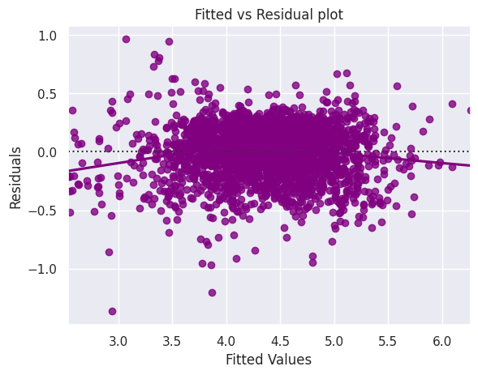

```python
# plot the fitted values vs residuals

sns.residplot(
    data=df_pred, x="Fitted Values", y="Residuals", color="purple", lowess=True
)
plt.xlabel("Fitted Values")
plt.ylabel("Residuals")
plt.title("Fitted vs Residual plot")
plt.show()
```

- The scatter plot shows the distribution of residuals (errors) vs fitted values (predicted values).
- If there exist any pattern in this plot, we consider it as signs of non-linearity in the data and a pattern means that the model doesn't capture non-linear effects.
- **We see no pattern in the plot above. Hence, the assumptions of linearity and independence are satisfied.**

### TEST FOR NORMALITY

- We will test for normality by checking the distribution of residuals, by checking the Q-Q plot of residuals, and by using the Shapiro-Wilk test.
- If the residuals follow a normal distribution, they will make a straight line plot, otherwise not.
- If the p-value of the Shapiro-Wilk test is greater than 0.05, we can say the residuals are normally distributed.

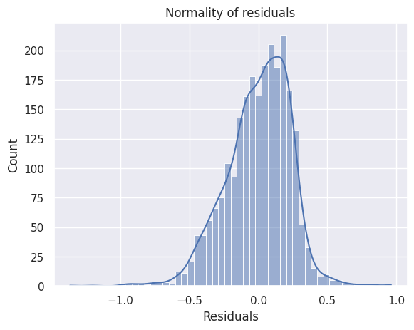

```python
# plot the distribution of residuals
sns.histplot(data=df_pred,  x="Residuals", kde=True)
plt.title("Normality of residuals")
plt.show()
```

The histogram of residuals does have a bell shape.

```
((array([-3.44385758, -3.19630236, -3.05919064, ...,  3.05919064,
          3.19630236,  3.44385758]),
  array([-1.36673332, -1.20219584, -0.96522884, ...,  0.83379501,
          0.94644703,  0.96416483])),
 (0.22884251340431236, 1.0087341531029639e-13, 0.986943890772691))
```

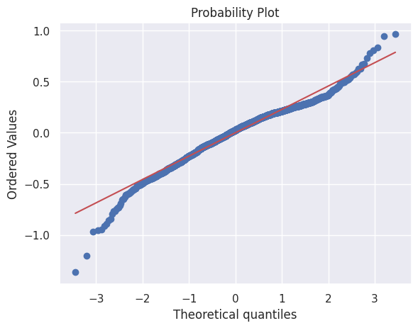

```python
import pylab
import scipy.stats as stats

# check Q-Q plot
plt.show()
stats.probplot(df_pred["Residuals"], dist="norm", plot=pylab)
```

The residuals more or less follow a straight line except for the tails.

```python
 # apply the Shapiro-Wilks test
stats.shapiro(df_pred["Residuals"])
```

```
ShapiroResult(statistic=0.9748184084892273, pvalue=3.1171865175534697e-20)
```

- Since p-value < 0.05, the residuals are not normal as per the Shapiro-Wilk test.
- Strictly speaking, the residuals are not normal.
- However, as an approximation, we can accept this distribution as close to being normal.
- **So, the assumption is satisfied.**

### TEST FOR HOMOSCEDASTICITY

- We will test for homoscedasticity by using the goldfeldquandt test.
- If we get a p-value greater than 0.05, we can say that the residuals are homoscedastic. Otherwise, they are heteroscedastic.

```python
import statsmodels.stats.api as sms
from statsmodels.compat import lzip

# apply the Goldfeldquandt test on the right train data
name = ["F statistic", "p-value"]
test = sms.het_goldfeldquandt(df_pred["Residuals"], x_train6)
lzip(name, test)
```

```
[('F statistic', 1.0643431899824785), ('p-value', 0.14163316519481514)]
```

**Since p-value > 0.05, we can say that the residuals are homoscedastic. So, this assumption is satisfied.**

```python
# predictions on the test set
pred = olsmodel2.predict(x_test6)

df_pred_test = pd.DataFrame({"Actual": y_test, "Predicted": pred})
df_pred_test.sample(10, random_state=1)
```

|  | Actual | Predicted |
| --- | --- | --- |
| 1995 | 4.566741 | 4.429951 |
| 2341 | 3.696103 | 3.947960 |
| 1913 | 3.592093 | 3.795452 |
| 688 | 4.306495 | 4.151106 |
| 650 | 4.522115 | 5.110160 |
| 2291 | 4.259294 | 4.415858 |
| 40 | 4.997685 | 5.419562 |
| 1884 | 3.875359 | 4.088954 |
| 2538 | 4.206631 | 4.000609 |
| 45 | 5.380450 | 5.283206 |

- We can observe here that our model has returned pretty good prediction results, and the actual and predicted values are comparable.
- We can also visualize comparison result as a bar graph.

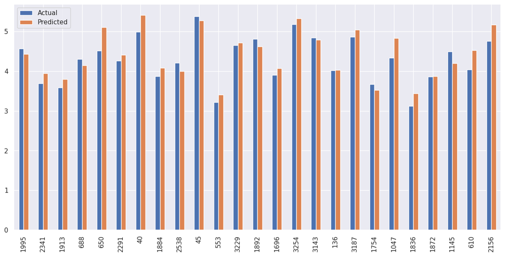

```python
df3 = df_pred_test.sample(25, random_state=1)
df3.plot(kind="bar", figsize=(15, 7))
plt.show()
```

## Final Model Summary

Recreate the final model and print it's summary to gain insights.

```python
x_train_final = x_train6.copy()
x_test_final = x_test6.copy()
```

```python
olsmodel_final = sm.OLS(y_train, x_train_final).fit()
print(olsmodel_final.summary())
```

```
                              OLS Regression Results
=================================================================================
Dep. Variable:     normalized_used_price   R-squared:                       0.843
Model:                               OLS   Adj. R-squared:                  0.841
Method:                    Least Squares   F-statistic:                     557.0
Date:                   Sun, 28 May 2023   Prob (F-statistic):               0.00
Time:                           06:31:38   Log-Likelihood:                 106.15
No. Observations:                   2417   AIC:                            -164.3
Df Residuals:                       2393   BIC:                            -25.33
Df Model:                             23
Covariance Type:               nonrobust
========================================================================================
                           coef    std err          t      P>|t|      [0.025      0.975]
----------------------------------------------------------------------------------------
const                    1.4815      0.050     29.447      0.000       1.383       1.580
screen_size              0.0454      0.001     31.462      0.000       0.043       0.048
selfie_camera_mp         0.0141      0.001     14.896      0.000       0.012       0.016
int_memory               0.0001   6.74e-05      2.161      0.031    1.35e-05       0.000
ram                      0.0168      0.004      3.769      0.000       0.008       0.026
normalized_new_price     0.4063      0.011     37.461      0.000       0.385       0.428
brand_name_Nokia         0.1206      0.031      3.919      0.000       0.060       0.181
brand_name_Samsung      -0.0389      0.016     -2.366      0.018      -0.071      -0.007
brand_name_Xiaomi        0.0693      0.026      2.702      0.007       0.019       0.120
4g_yes                   0.0612      0.014      4.481      0.000       0.034       0.088
main_camera_mp_8.0      -0.1057      0.014     -7.758      0.000      -0.132      -0.079
main_camera_mp_5.0      -0.1676      0.017     -9.780      0.000      -0.201      -0.134
main_camera_mp_3.15     -0.2256      0.030     -7.537      0.000      -0.284      -0.167
main_camera_mp_2.0      -0.2254      0.026     -8.589      0.000      -0.277      -0.174
main_camera_mp_16.0      0.0992      0.024      4.091      0.000       0.052       0.147
main_camera_mp_0.3      -0.4002      0.039    -10.179      0.000      -0.477      -0.323
main_camera_mp_48.0      0.2858      0.117      2.445      0.015       0.057       0.515
main_camera_mp_1.3      -0.4224      0.061     -6.878      0.000      -0.543      -0.302
main_camera_mp_23.0      0.2516      0.068      3.717      0.000       0.119       0.384
main_camera_mp_4.0      -0.3201      0.096     -3.348      0.001      -0.508      -0.133
main_camera_mp_10.0     -0.2745      0.117     -2.344      0.019      -0.504      -0.045
main_camera_mp_6.7      -0.2760      0.121     -2.284      0.022      -0.513      -0.039
main_camera_mp_16.3      0.5577      0.234      2.385      0.017       0.099       1.016
main_camera_mp_8.1      -0.3139      0.118     -2.669      0.008      -0.545      -0.083
==============================================================================
Omnibus:                      189.291   Durbin-Watson:                   1.912
Prob(Omnibus):                  0.000   Jarque-Bera (JB):              341.294
Skew:                          -0.554   Prob(JB):                     7.74e-75
Kurtosis:                       4.470   Cond. No.                     4.73e+03
==============================================================================

Notes:
[1] Standard Errors assume that the covariance matrix of the errors is correctly specified.
[2] The condition number is large, 4.73e+03. This might indicate that there are
strong multicollinearity or other numerical problems.
```

```python
# checking model performance on train set (seen 70% data)
print("Training Performance\n")
olsmodel_final_train_perf = model_performance_regression(olsmodel_final, x_train_final, y_train)
olsmodel_final_train_perf
```

```
Training Performance
```

|  | RMSE | MAE | R-squared | Adj. R-squared | MAPE |
| --- | --- | --- | --- | --- | --- |
| 0 | 0.231574 | 0.181885 | 0.842597 | 0.841017 | 4.359256 |

```python
# checking model performance on test set (seen 30% data)
print("Test Performance\n")
olsmodel_final_test_perf = model_performance_regression(olsmodel_final, x_test_final, y_test)
olsmodel_final_test_perf
```

```
Test Performance
```

|  | RMSE | MAE | R-squared | Adj. R-squared | MAPE |
| --- | --- | --- | --- | --- | --- |
| 0 | 0.241613 | 0.18775 | 0.838147 | 0.834309 | 4.560502 |

## Actionable Insights and Recommendations

- The normalized_new_price demonstrates a strong positive correlation with the used price. Consequently, as the price of a new device increases, the price of the same device in the refurbished market also rises.
- For every one unit increase in the device's screen size, the price of the refurbished device increases by 0.0454 units. It would most likely be beneficial for retailers to sell refurbished devices that have larger screen sizes as they will bring in the most revenue.
- Positive coefficients are observed for screen_size, selfie_camera_mp, int_memory, ram, normalized_new_price, some brands, and 4G. As these factors increase, the price of used devices also increases.
- On the other hand, the brand of Samsung and various main camera mega pixel configurations have negative coefficients. Therefore, as these factorss increase, the price of used devices decreases.
- Retailers should focus their eforts in distributing reurbished devices from specif brands that have positive coefficients as these are the devices that will maximize profits.